## Electricity Generation Forecast 2020 - 2050 for Canada by Resource type

##### [Abhinav Parbhakar](https://www.linkedin.com/in/abhinav-parbhakar-51b5a024a/)

We see the topic of climate change and global warming everywhere we look, coupled with buzzwords thrown around by politicians to get votes.

I believe that the benefits behind the shift towards using renewable primary fuel for electricity generation can be analyzed by looking at the graph of Canada’s projected [electricity generation, under the Evolving Policies case](https://apps.cer-rec.gc.ca/ftrppndc/dflt.aspx?GoCTemplateCulture=en-CA), the case which assumes that action to reduce the GHG emssions by Canada’s energy sector will continue to [increase](https://www.cer-rec.gc.ca/en/data-analysis/canada-energy-future/2021/scenarios-and-assumptions.html#scenario-premise).

The reason for which this graph should be considered timely is simple - many politicians will advertise themselves as *enviroment-friendly* candidates and will use the Evolving Policies case as the underlying backbone of this claim.

What this graph will do for **YOU**, is display the projections for the next 30 years, given this scenario, just in time to provide valuable information before the upcoming election cycles, no matter what political belief you hold.

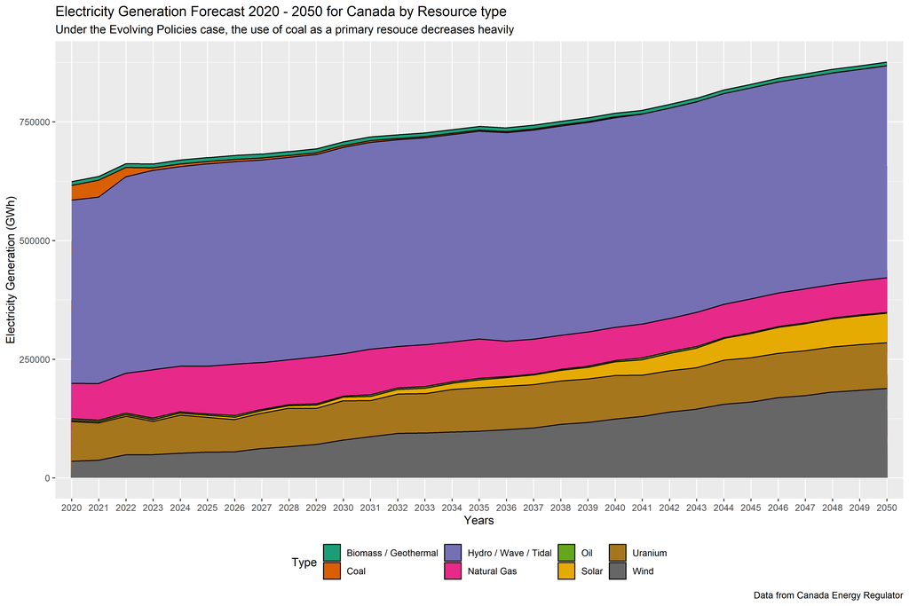

#### About the author

I am a 3rd year student pursuing a BSc in Computing Science with an interest in Economics. My interests including cooking, rock-climbing, going to the gym, and developing websites.